# QWEAssignment_RanDou_QimoLi

Ran Dou, Qimo Li

10/25/2018

## BUS256a: Marketing Analytics

### Predicting Customer Churn at QWE Inc.

```r
#Clears the environment window pane in RStudio
rm(list=ls())

#Set work directory to where includes the HomeZilla data
#setwd("~/Esther/Brandeis/2018 Fall/4 BUS256A Marketing Analytics  Bhoomija Ranjan/Analysis/Analysis 3")
setwd("~/Desktop")

#Install required packages
pkg <- c("tidyverse", "knitr", "readxl", "RColorBrewer", "grid", "sjPlot")  #a list of packages
pkg.uninstalled <- pkg[!(pkg %in% installed.packages())]
if (length(pkg.uninstalled)) {install.packages(new.pkg, repos ="http://cran.rstudio.com")}

#Library packages
library(tidyverse)
library(knitr)
library(readxl)  #library package required for using read_excel()
library(RColorBrewer)  #required for using display.brewer.all()
library(grid)  #required for using grid.layout()
library(sjPlot)  #required for using sjt.df() to convert regression summay into beautiful format
library(scales)
library(broom)  #required for using tidy() on t.test
```

### PART 1 Introduction

Richard Wall’s objectives of looking at customer churn at QWE Inc. is to estimate the probability that a given customer would unsubscribe the service in the future and identify the factors that contributed most to that customer’s decision, so that his team would be able to improve customers’ experience more specific to decrease the churn rate. In other words, he wants to use historical data to determine the probability of churn within two months.  
After being asked to take on the project, V.J.Aggrawal, Richard’s associates, first researched available data to build up the fundamental database, which obtained 6000 samples and more than 230 data fields for each sample. Then he discussed with Richard and filtered out the most important characteristics: Customer age, CHI, and service and usage patterns. Finally, Aggrawal pulled data on the value of December 1, 2011, and its change from November to December, and he added a dummy variable to indicate whether the customer left in the two months following December 1.  
The problem Aggrawal met while constructing the churn data set is that when dealing with the service and usage patterns, a high activity rate on reporting problems can either indicates that the customer is more likely to drop or he/she is actively using the system.

### PART 2 Data Description & Cleaning

```r
#Read in the "Case Data" page from the QWE Inc. Excel file into R
QWE <- read_excel("UV6696-XLS-ENG.xlsx", sheet = 2)
#Provide a summary of the data
summary <- as.data.frame(do.call(cbind, lapply(QWE, summary)))
QWEsummary <- modify_if(summary, ~is.numeric(.), ~round(., 2))
kable(QWEsummary)
```

|  | ID | Customer Age (in months) | Churn (1 = Yes, 0 = No) | CHI Score Month 0 | CHI Score 0-1 | Support Cases Month 0 | Support Cases 0-1 | SP Month 0 | SP 0-1 | Logins 0-1 | Blog Articles 0-1 | Views 0-1 | Days Since Last Login 0-1 |
| --- | --- | --- | --- | --- | --- | --- | --- | --- | --- | --- | --- | --- | --- |
| Min. | 1.0 | 0.0 | 0.00 | 0.00 | -125.00 | 0.00 | -29.00 | 0.00 | -4.00 | -293.00 | -75.00 | -28322.00 | -648.00 |
| 1st Qu. | 1587.5 | 5.0 | 0.00 | 24.50 | -8.00 | 0.00 | 0.00 | 0.00 | 0.00 | -1.00 | 0.00 | -11.00 | 0.00 |
| Median | 3174.0 | 11.0 | 0.00 | 87.00 | 0.00 | 0.00 | 0.00 | 0.00 | 0.00 | 2.00 | 0.00 | 0.00 | 0.00 |
| Mean | 3174.0 | 13.9 | 0.05 | 87.32 | 5.06 | 0.71 | -0.01 | 0.81 | 0.03 | 15.73 | 0.16 | 96.31 | 1.76 |
| 3rd Qu. | 4760.5 | 20.0 | 0.00 | 139.00 | 15.00 | 1.00 | 0.00 | 2.67 | 0.00 | 23.00 | 0.00 | 27.00 | 3.00 |
| Max. | 6347.0 | 67.0 | 1.00 | 298.00 | 208.00 | 32.00 | 31.00 | 4.00 | 4.00 | 865.00 | 217.00 | 230414.00 | 61.00 |

There are 13 variables in the QWE data frame, the summaries of each variable are shown in the table above. The first column shows the customer ID, which is the primary key of this data frame. The second column shows the age of each customer. The third column indicates whether the customer left in the two months following December 1, 2011. Other variables with `0` at the end are the value of December 2011, and the variables with `0-1` at the end means the difference between December and November 2011.

**Explanation for the following terms used in the case:**  
i. `Month 0` denotes the current moment in time, namely December 2011. ii. `0-1` shows the difference value between Month 0 and a month before, namely the value difference between December 2011 and November 2011.  
iii. `Churn` is the behavior of customers who decide to unsubscribe the service from the company.  
iv. `Support Cases` indicates how many times the customer met problems while using the system. v. `Support Priority` indicates the priority level depending on how serious the issue is. vi. `Usage`(logins, blog articles, views, days since last login) indicates the active level of the usage of the system, higher active level leads the customers to see more value in the service.

```r
#Check the data-types of variables
QWEdatatype <- QWE %>% summarise_all(typeof) %>% gather
names(QWEdatatype) <- c("Variables", "Data Type")
QWEdatatype$Detail <- c("Discrete","Discrete","Discrete","Continuous","Continuous","Discrete","Discrete","Discrete","Discrete","Discrete","Discrete","Discrete","Discrete")
kable(QWEdatatype, align = "c")
```

| Variables | Data Type | Detail |
| --- | --- | --- |
| ID | double | Discrete |
| Customer Age (in months) | double | Discrete |
| Churn (1 = Yes, 0 = No) | double | Discrete |
| CHI Score Month 0 | double | Continuous |
| CHI Score 0-1 | double | Continuous |
| Support Cases Month 0 | double | Discrete |
| Support Cases 0-1 | double | Discrete |
| SP Month 0 | double | Discrete |
| SP 0-1 | double | Discrete |
| Logins 0-1 | double | Discrete |
| Blog Articles 0-1 | double | Discrete |
| Views 0-1 | double | Discrete |
| Days Since Last Login 0-1 | double | Discrete |

According to the analysis above, we figured out that all variables are stored as numeric data. Among all the variables, only `CHI Score Month 0` and `CHI Score 0-1` are continuous variables because CHI Score indicates customers’ satisfaction level so that it can take float values.  
Moreover, although `Churn (1 = Yes, 0 = No)` should be considered as a factor variable, we decided not to convert its data type because we will use it as a numerical data in the analyses below.

### PART 3 Visualizations

#### a. Distribution of CHI score for December 2011 by different churn outcomes.

```r
p1 <- QWE %>% ggplot(aes(x = `CHI Score Month 0`, fill = factor(`Churn (1 = Yes, 0 = No)`))) +
  geom_histogram(binwidth = 30, alpha = 0.5, color = "white") +
  stat_bin(binwidth = 30, geom="text", family = "Times New Roman", size=3,
           aes(label=..count.., group = factor(`Churn (1 = Yes, 0 = No)`), y=..count..+ 100)) +
  ggtitle("plot 1: Distribution of CHI Score for December 2011 by Different Churn Outcomes") +
  labs(x = "CHI score for December 2011", y = "Count", fill = "Churn Outcomes") +
  scale_fill_manual(labels = c("Unchurn", "Churn"), values = c("black", "red")) +
  theme_minimal(base_family = "Times New Roman") +
  theme(legend.position = "bottom", plot.title = element_text(hjust = 0.5))
p2 <- QWE %>% filter(`Churn (1 = Yes, 0 = No)` == 0) %>%
  ggplot(aes(x = `CHI Score Month 0`)) +
  geom_histogram(binwidth = 30, alpha = 0.5, color = "white", fill = "black") +
  geom_vline(aes(xintercept = mean(`Churn (1 = Yes, 0 = No)`)), color = "red") +
  stat_bin(binwidth = 30, geom="text", family = "Times New Roman", size=3,
           aes(label=..count.., y=..count..+ 50)) +
  ggtitle("plot 2: CHI Score for Unchurned Customers") +
  labs(x = "CHI score for December 2011", y = "Count") +
  theme_minimal(base_family = "Times New Roman") +
  theme(legend.position = "bottom", plot.title = element_text(hjust = 0.5))
p3 <- QWE %>% filter(`Churn (1 = Yes, 0 = No)` == 1) %>%
  ggplot(aes(x = `CHI Score Month 0`)) +
  geom_histogram(binwidth = 30, alpha = 0.5, color = "white", fill = "red") +
  geom_vline(aes(xintercept = mean(`Churn (1 = Yes, 0 = No)`)), color = "black") +
  stat_bin(binwidth = 30, geom="text", family = "Times New Roman", size=3,
           aes(label=..count.., y=..count..+ 5)) +
  ggtitle("plot 3: CHI Score for Churned Customers") +
  labs(x = "CHI score for December 2011", y = "Count") +
  theme_minimal(base_family = "Times New Roman") +
  theme(legend.position = "bottom", plot.title = element_text(hjust = 0.5))
```

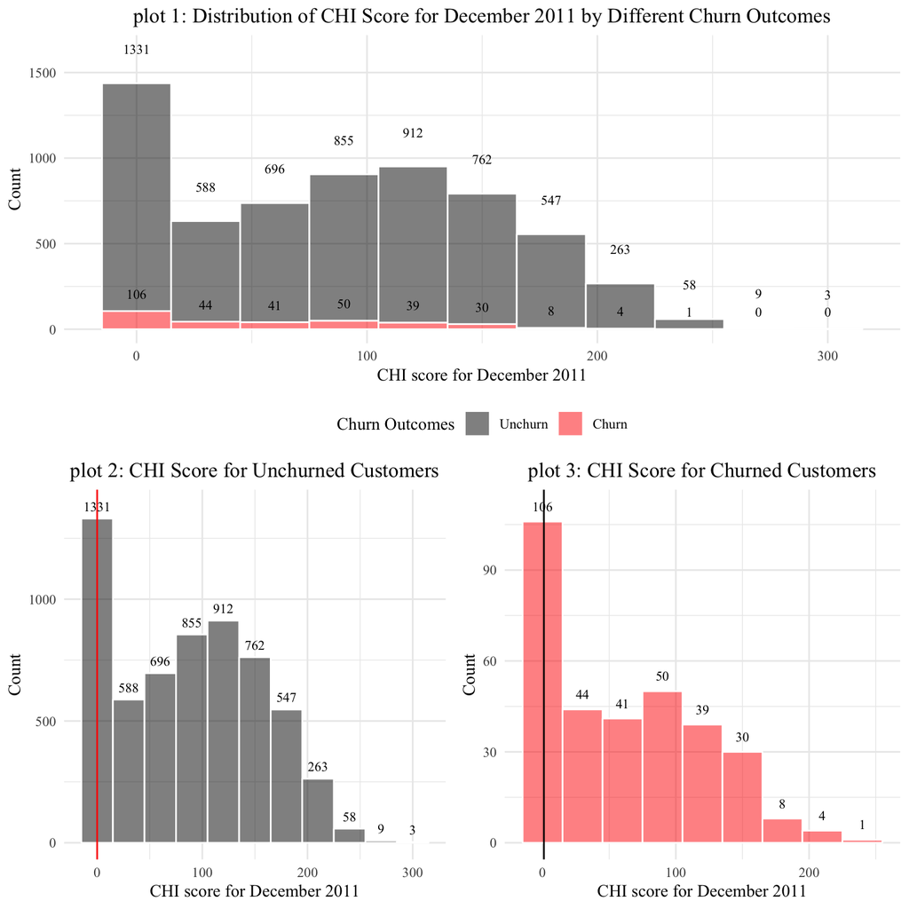

```r
#define a function to be used on plotting
vplayout <- function(x,y){viewport(layout.pos.row = x, layout.pos.col = y)}
grid.newpage()  #create a new grid for the plots
pushViewport(viewport(layout = grid.layout(2,2))) #change the composition of the grid
print(p1, vp = vplayout(1,1:2))
print(p2, vp = vplayout(2,1))
print(p3, vp = vplayout(2,2))
```

```r
mean_unchurn <- mean(QWE$`CHI Score Month 0`[QWE$`Churn (1 = Yes, 0 = No)`==0])
mean_churn <- mean(QWE$`CHI Score Month 0`[QWE$`Churn (1 = Yes, 0 = No)`==1])
sprintf("Mean CHI score of unchurned customers is %f", mean_unchurn)
```

```
## [1] "Mean CHI score of unchurned customers is 88.605910"
```

```r
sprintf("Mean CHI score of churned customers is %f", mean_churn)
```

```
## [1] "Mean CHI score of churned customers is 63.272446"
```

Plot 1 shows the total distribution of CHI score for December 2011 by different churn outcomes. Plot 2 and plot 3 show the distribution of CHI score for unchurned and churned customers. From the three plots, we observed that both groups have most customers with 0 to 30 CHI score, which might be caused by the deficiency of data (resulted in 0 score). Aside from this time interval, unchurned customers seem to have the peak value with 120 to 150 CHI score, while the number of churned customers seem to decrease as the CHI score goes higher. Therefore, we made preliminary conjecture that customers who churned generally have lower CHI scores than customers who didn’t left. With further mathematical analysis, we figured out that the mean CHI score of unchurned customers is 88.61 and the mean CHI score of churned customers is 63.27, this phenomenon proves our previous conjecture. In conclusion, its reasonable for us to believe that CHI score does have negative correlation with the possibility of whether a customer decided to churn.

#### b. Average churn rate by customer age

```r
QWE_part3 <- QWE %>% group_by(`Customer Age (in months)`) %>%
  summarise(`Average Churn Rate` = mean(`Churn (1 = Yes, 0 = No)`))

QWE_part3b <- QWE %>%
  mutate(`Customer Age` = cut(`Customer Age (in months)`, breaks = c(-Inf, 10, 20, 30, 40, 50, 60, Inf), labels = c("0 to 10 months", "10 to 20 months", "20 to 30 months", "30 to 40 months", "40 to 50 months", "50 to 60 months", "over 60 months"))) %>%
  group_by(`Customer Age`, `Churn (1 = Yes, 0 = No)`) %>%
  summarize(n = n()) %>%
  spread(`Churn (1 = Yes, 0 = No)`, n) %>%
  mutate(`1` = ifelse(is.na(`1`) == TRUE, 0, `1`), `Churn Rate` = `1`/(`0`+`1`))

p4 <- QWE_part3 %>%
  ggplot(aes(x = `Customer Age (in months)`, y = `Average Churn Rate`)) +
  geom_point() +
  ggtitle("plot 4: Average Churn Rate by Customer Age") +
  scale_y_continuous(labels = percent_format()) +  #change lables on the y-axis to percentage format
  labs(x = "Age", y = "Average Churn Rate") +
  theme_minimal(base_family = "Times New Roman") +
  theme(legend.position = "bottom", plot.title = element_text(hjust = 0.5))

p5 <- QWE_part3b %>%
  ggplot(aes(x = `Customer Age`)) +
  geom_point(aes(y = `0`/30000), size = 6, color = "black", alpha = 0.5) +
  geom_point(aes(y = `1`/30000), size = 6, color = "red", alpha = 0.5) +
  geom_text(aes(label = `0`, y = `0`/30000+0.002),family = "Times New Roman", size = 3, hjust = -0.5) +
  geom_text(aes(label = `1`, y = `1`/30000),family = "Times New Roman", size = 3, hjust = -1.5) +
  geom_line(aes(y = `Churn Rate`), group = 1) +
  geom_point(aes(y = `Churn Rate`)) +
  ggtitle("plot 5: Average Churn Rate by Customer Age Groups") +
  geom_text(aes(x = `Customer Age`, label = scales::percent(`Churn Rate`), y = `Churn Rate`), family = "Times New Roman", size = 4, vjust = -2) +
  scale_y_continuous(labels = percent_format(), name = expression("Churn Rate"),
    sec.axis = sec_axis(~ . *30000 , name = "Number of Customer")) +
  theme_minimal(base_family = "Times New Roman") +
  theme(plot.title = element_text(hjust = 0.5))
```

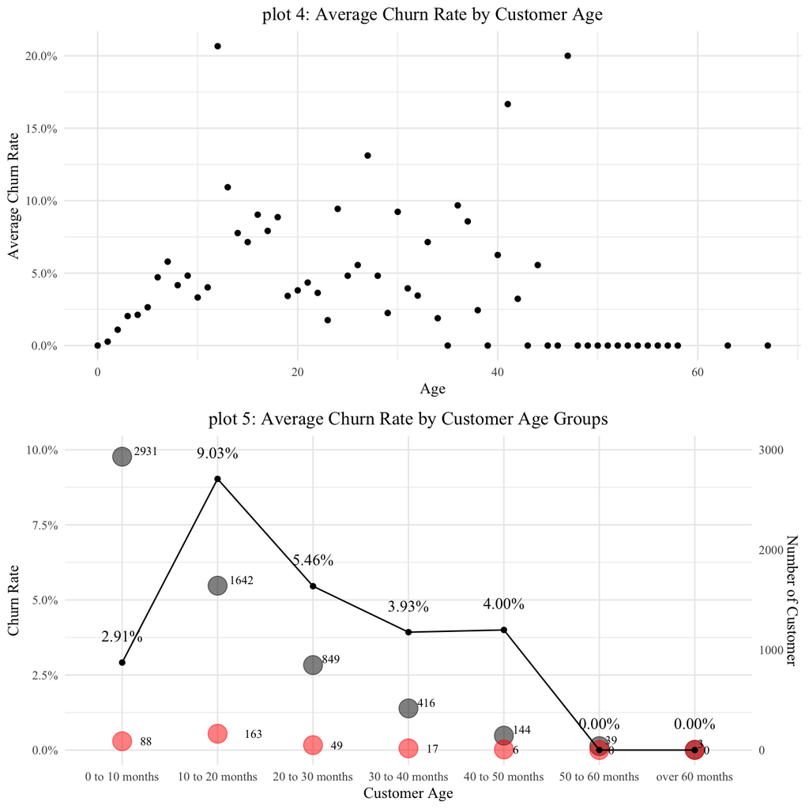

```r
grid.newpage()  #create a new grid for the plots
pushViewport(viewport(layout = grid.layout(2,1))) #change the composition of the grid
print(p4, vp = vplayout(1,1))
print(p5, vp = vplayout(2,1))
```

[figure not shown]

```r
QWE %>% group_by(`Customer Age (in months)`) %>%
  summarise(`Number of Customers` = n()) %>%
  ggplot(aes(x = `Customer Age (in months)`, y = `Number of Customers`)) +
  geom_point() +
  geom_smooth(se = FALSE, color = "red", size = 0.5) +
  ggtitle("plot 6: Number of Customer Who Churn by Customer Age") +
  theme_minimal(base_family = "Times New Roman") +
  theme(legend.position = "bottom", plot.title = element_text(hjust = 0.5))
```

### PART 4 Statistical Analyses

```r
#create a function to generate the required three statistics
Statistics <- function(x){
   table = round(tidy(t.test(x[QWE$`Churn (1 = Yes, 0 = No)`==1], x[QWE$`Churn (1 = Yes, 0 = No)`==0]), pair = FALSE)[c(2,3,5)],8)
   return(table)
}
#apply the function to the 11 variables and save the result as a data frame
t_result <- as.data.frame(sapply(QWE[,c(2,4:13)], Statistics))
#add row names as the first column, and change the name of the second to the fourth columns
t_result_table <- as.data.frame(t(t_result)) %>%
  add_rownames("Variable Name") %>%
  rename(`Mean for Churned Customers` = estimate1, `Mean for Unchurned Customers` = estimate2, `p-value` = `p.value`)
#show the eventually result using kable
kable(t_result_table)
```

| Variable Name | Mean for Churned Customers | Mean for Unchurned Customers | p-value |
| --- | --- | --- | --- |
| Customer Age (in months) | 15.35294118 | 13.8187251 | 0.00305679 |
| CHI Score Month 0 | 63.27244582 | 88.60590969 | 0 |
| CHI Score 0-1 | -3.73684211 | 5.53021248 | 2e-08 |
| Support Cases Month 0 | 0.37151703 | 0.72426959 | 6e-08 |
| Support Cases 0-1 | 0.0371517 | -0.00929615 | 0.5277532 |
| SP Month 0 | 0.49955772 | 0.82957589 | 4.4e-07 |
| SP 0-1 | -0.01669615 | 0.03268184 | 0.5218233 |
| Logins 0-1 | 8.0619195 | 16.13894422 | 0.00040374 |
| Blog Articles 0-1 | -0.10216718 | 0.17114874 | 0.01157611 |
| Views 0-1 | -95.76780186 | 106.60956175 | 0.05630696 |
| Days Since Last Login 0-1 | 6.48606811 | 1.51145418 | 5.215e-05 |

We performed a t-test on the difference of the means of all 11 variables (barring ID) for customers who churned and who didn’t. The t-test helped us to check whether the difference of the means is statistically different from 0 significantly. The result of the t-test indicates that whether a variable differs significantly by churn outcome.
The null hypothesis ($H_0$) for the test is that the difference of the mean between customers who churned and who didn’t is equals to zero. In other words, the variable does not differ significantly by churn outcome. The alternative hypothesis ($H_1$) for the test is that the difference of the mean between customers who churned and who didn’t churn is not equal to zero. In other words, the variable differs significantly by churn outcome.
$$H_0: Mean_{churned}-Mean_{unchurned}=0\\
H_1: Mean_{churned}-Mean_{unchurned}\neq0$$
According to the results of statistical tests above, at 5% significance level, the mean of the following eight variables differ significantly across the two groups: `Customer Age (in months)`, `CHI Score Month 0`, `CHI Score 0-1`, `Support Cases Month 0`, `SP Month 0`, `Logins 0-1`, `Blog Articles 0-1`, `Days Since Last Login 0-1` because their p-values are below 0.05. Therefore, it’s reasonable for us to reject the null hypothesis on these variables and in favor of the alternative hypothesis that the mean of these variables differs significantly across the customers who churned and who didn’t. According to the statistical analyses, the managerial group should pay more attention to the eight variables mentioned before because they have statistically significant coefficients with the churn outcome. For example, they can use the difference number of blog articles for two months (`Blog Articles 0-1`) to estimate whether a customer tends to churn or not.

### PART 5 Logistic Regression

```r
#run general linear regression on customer churn
glm_churn <- glm(`Churn (1 = Yes, 0 = No)`~`Customer Age (in months)` + `CHI Score Month 0` + `CHI Score 0-1` + `Support Cases Month 0` + `Support Cases 0-1` + `SP Month 0` + `SP 0-1` + `Logins 0-1` + `Blog Articles 0-1` + `Views 0-1` + `Days Since Last Login 0-1`, data = QWE)

#show the result of the regression in a statistic table
tab_model(glm_churn, show.se = TRUE, show.stat = TRUE, show.p = TRUE, digits = 4, digits.p = 4)
```

|  | Churn(1=Yes,0=No) |  |  |  |  |
| --- | --- | --- | --- | --- | --- |
| Predictors | Estimates | std. Error | CI | Statistic | p |
| (Intercept) | 0.0636 | 0.0053 | 0.0533 – 0.0739 | 12.0926 | **<0.001** |
| `Customer Age (in months)` | 0.0008 | 0.0003 | 0.0003 – 0.0014 | 3.0907 | **0.0020** |
| `CHI Score Month 0` | -0.0003 | 0.0001 | -0.0004 – -0.0001 | -4.7035 | **<0.001** |
| `CHI Score 0-1` | -0.0004 | 0.0001 | -0.0006 – -0.0002 | -3.4708 | **0.0005** |
| `Support Cases Month 0` | -0.0013 | 0.0026 | -0.0064 – 0.0039 | -0.4837 | 0.6286 |
| `Support Cases 0-1` | 0.0029 | 0.0021 | -0.0013 – 0.0071 | 1.3685 | 0.1712 |
| `SP Month 0` | -0.0017 | 0.0038 | -0.0091 – 0.0056 | -0.4628 | 0.6435 |
| `SP 0-1` | -0.0002 | 0.0029 | -0.0059 – 0.0055 | -0.0774 | 0.9383 |
| `Logins 0-1` | 0.0000 | 0.0001 | -0.0001 – 0.0002 | 0.4634 | 0.6431 |
| `Blog Articles 0-1` | 0.0001 | 0.0006 | -0.0011 – 0.0013 | 0.1241 | 0.9012 |
| `Views 0-1` | -0.0000 | 0.0000 | -0.0000 – 0.0000 | -0.8833 | 0.3771 |
| `Days Since Last Login 0-1` | 0.0006 | 0.0002 | 0.0003 – 0.0009 | 4.1678 | **<0.001** |
| Observations | 6347 |  |  |  |  |
| Cox & Snell’s R<sup>2</sup> / Nagelkerke’s R<sup>2</sup> | 0.001 / 0.016 |  |  |  |  |

**The significant factors affecting customer churn**

According to the result of general linear regression, there are eleven independent variables. Among the independent variables, only four are significant: `Customer Age (in months)`, `CHI Score Month 0`, `CHI Score 0-1`, `Days Since Last Login 0-1`. These four variables have p-values less than 0.05, which means that at 5 percent significance level, the null hypothesis, that the coefficient estimator is equal to zero, can be rejected. Thus, for the four variables, we in favor of the alternative hypothesis that the estimators for them are statistically different from zero, which means that they can be considered as significant factors affecting customer churn. Among these variables, `Customer Age (in months)` and `Days Since Last Login 0-1` have a positive correlation with the possibility of churn with estimators of 0.0008 and 0.0006. `CHI Score Month 0` and `CHI Score 0-1` have a negative correlation with the possibility of churn with estimators of -0.0003 and -0.0004.

**Lesson for Aggarwal and Wall**

From the regression result, Aggarwal and Wall should learn that the four most important factors that influence customers’ churn outcomes are 1) how long they have been with QWE, 2) CHI score, 3) the change of CHI score, 4) how often they login the website. Therefore, they should work hard on analyzing these variables to decide which segment to focus.

### PART 6 Customer Segmentation

##### a. Create segments in the data based on customer age - “New” (0-6 months), “Medium” (7-12 months), “Old” (13+ months).

```r
#use cut() to breack customers into three age groups
QWE <- QWE %>%
  mutate(segment = cut(`Customer Age (in months)`, breaks = c(-Inf, 6, 12, Inf), labels = c('New', 'Medium', 'Old')))
```

##### b. Perform logistic regression as part (5) above for each segment separately

```r
#filter out the customers for each group and save as three new data frame
QWEnew <- QWE[QWE$segment=='New',]
QWEmedium <- QWE[QWE$segment=='Medium',]
QWEold <- QWE[QWE$segment=='Old',]

#run general linear regression on each group
glm_new <- glm(`Churn (1 = Yes, 0 = No)`~`Customer Age (in months)` + `CHI Score Month 0` + `CHI Score 0-1` + `Support Cases Month 0` + `Support Cases 0-1` + `SP Month 0` + `SP 0-1` + `Logins 0-1` + `Blog Articles 0-1` + `Views 0-1` + `Days Since Last Login 0-1`, data = QWEnew)
glm_medium <- glm(`Churn (1 = Yes, 0 = No)`~`Customer Age (in months)` + `CHI Score Month 0` + `CHI Score 0-1` + `Support Cases Month 0` + `Support Cases 0-1` + `SP Month 0` + `SP 0-1` + `Logins 0-1` + `Blog Articles 0-1` + `Views 0-1` + `Days Since Last Login 0-1`, data = QWEmedium)
glm_old <- glm(`Churn (1 = Yes, 0 = No)`~`Customer Age (in months)` + `CHI Score Month 0` + `CHI Score 0-1` + `Support Cases Month 0` + `Support Cases 0-1` + `SP Month 0` + `SP 0-1` + `Logins 0-1` + `Blog Articles 0-1` + `Views 0-1` + `Days Since Last Login 0-1`, data = QWEold)

#show the result of three regressions in the table
tab_model(glm_new, show.se = TRUE, show.stat = TRUE, show.p = TRUE, digits = 4, digits.p = 4, title = "Segment: New")
```

Segment: New

|  | Churn(1=Yes,0=No) |  |  |  |  |
| --- | --- | --- | --- | --- | --- |
| Predictors | Estimates | std. Error | CI | Statistic | p |
| (Intercept) | -0.0071 | 0.0076 | -0.0220 – 0.0078 | -0.9379 | 0.3484 |
| `Customer Age (in months)` | 0.0101 | 0.0026 | 0.0050 – 0.0153 | 3.8735 | **0.0001** |
| `CHI Score Month 0` | -0.0002 | 0.0001 | -0.0004 – 0.0000 | -1.6110 | 0.1073 |
| `CHI Score 0-1` | -0.0004 | 0.0001 | -0.0006 – -0.0001 | -2.8430 | **0.0045** |
| `Support Cases Month 0` | -0.0034 | 0.0024 | -0.0082 – 0.0014 | -1.3858 | 0.1660 |
| `Support Cases 0-1` | 0.0039 | 0.0020 | 0.0001 – 0.0078 | 1.9918 | **0.0465** |
| `SP Month 0` | 0.0080 | 0.0049 | -0.0016 – 0.0176 | 1.6294 | 0.1034 |
| `SP 0-1` | -0.0044 | 0.0038 | -0.0119 – 0.0030 | -1.1683 | 0.2428 |
| `Logins 0-1` | 0.0002 | 0.0001 | 0.0000 – 0.0004 | 2.3852 | **0.0172** |
| `Blog Articles 0-1` | 0.0000 | 0.0005 | -0.0010 – 0.0010 | 0.0683 | 0.9456 |
| `Views 0-1` | 0.0000 | 0.0000 | -0.0000 – 0.0000 | 0.6918 | 0.4891 |
| `Days Since Last Login 0-1` | 0.0002 | 0.0002 | -0.0002 – 0.0006 | 0.8921 | 0.3724 |
| Observations | 2051 |  |  |  |  |
| Cox & Snell’s R<sup>2</sup> / Nagelkerke’s R<sup>2</sup> | 0.000 / 0.022 |  |  |  |  |

```r
tab_model(glm_medium, show.se = TRUE, show.stat = TRUE, show.p = TRUE, digits = 4, digits.p = 4, title = "Segment: Medium")
```

Segment: Medium

|  | Churn(1=Yes,0=No) |  |  |  |  |
| --- | --- | --- | --- | --- | --- |
| Predictors | Estimates | std. Error | CI | Statistic | p |
| (Intercept) | -0.0476 | 0.0382 | -0.1225 – 0.0272 | -1.2473 | 0.2125 |
| `Customer Age (in months)` | 0.0203 | 0.0038 | 0.0129 – 0.0277 | 5.3897 | **<0.001** |
| `CHI Score Month 0` | -0.0007 | 0.0001 | -0.0009 – -0.0004 | -5.1397 | **<0.001** |
| `CHI Score 0-1` | -0.0001 | 0.0003 | -0.0007 – 0.0004 | -0.4633 | 0.6432 |
| `Support Cases Month 0` | 0.0034 | 0.0068 | -0.0099 – 0.0167 | 0.5037 | 0.6145 |
| `Support Cases 0-1` | -0.0005 | 0.0051 | -0.0106 – 0.0096 | -0.0967 | 0.9230 |
| `SP Month 0` | -0.0137 | 0.0086 | -0.0305 – 0.0031 | -1.5990 | 0.1100 |
| `SP 0-1` | 0.0043 | 0.0063 | -0.0081 – 0.0167 | 0.6793 | 0.4971 |
| `Logins 0-1` | 0.0000 | 0.0002 | -0.0003 – 0.0004 | 0.2851 | 0.7756 |
| `Blog Articles 0-1` | -0.0005 | 0.0024 | -0.0052 – 0.0042 | -0.2100 | 0.8337 |
| `Views 0-1` | -0.0000 | 0.0000 | -0.0000 – 0.0000 | -0.4871 | 0.6263 |
| `Days Since Last Login 0-1` | 0.0015 | 0.0004 | 0.0007 – 0.0023 | 3.6627 | **0.0003** |
| Observations | 1513 |  |  |  |  |
| Cox & Snell’s R<sup>2</sup> / Nagelkerke’s R<sup>2</sup> | 0.005 / 0.070 |  |  |  |  |

```r
tab_model(glm_old, show.se = TRUE, show.stat = TRUE, show.p = TRUE, digits = 4, digits.p = 4, title = "Segment: Old")
```

Segment: Old

|  | Churn(1=Yes,0=No) |  |  |  |  |
| --- | --- | --- | --- | --- | --- |
| Predictors | Estimates | std. Error | CI | Statistic | p |
| (Intercept) | 0.1771 | 0.0153 | 0.1471 – 0.2071 | 11.5686 | **<0.001** |
| `Customer Age (in months)` | -0.0019 | 0.0005 | -0.0029 – -0.0010 | -4.0389 | **0.0001** |
| `CHI Score Month 0` | -0.0006 | 0.0001 | -0.0008 – -0.0005 | -7.2199 | **<0.001** |
| `CHI Score 0-1` | -0.0000 | 0.0002 | -0.0004 – 0.0004 | -0.1625 | 0.8709 |
| `Support Cases Month 0` | 0.0002 | 0.0058 | -0.0110 – 0.0115 | 0.0411 | 0.9673 |
| `Support Cases 0-1` | 0.0009 | 0.0050 | -0.0088 – 0.0106 | 0.1839 | 0.8541 |
| `SP Month 0` | -0.0027 | 0.0066 | -0.0156 – 0.0102 | -0.4079 | 0.6834 |
| `SP 0-1` | 0.0021 | 0.0052 | -0.0081 – 0.0122 | 0.3977 | 0.6909 |
| `Logins 0-1` | -0.0000 | 0.0001 | -0.0003 – 0.0002 | -0.2252 | 0.8218 |
| `Blog Articles 0-1` | 0.0002 | 0.0012 | -0.0022 – 0.0026 | 0.1810 | 0.8564 |
| `Views 0-1` | -0.0000 | 0.0000 | -0.0000 – 0.0000 | -0.5181 | 0.6044 |
| `Days Since Last Login 0-1` | 0.0001 | 0.0002 | -0.0003 – 0.0006 | 0.5538 | 0.5798 |
| Observations | 2783 |  |  |  |  |
| Cox & Snell’s R<sup>2</sup> / Nagelkerke’s R<sup>2</sup> | 0.002 / 0.035 |  |  |  |  |

Which variables consistently affect all segments? Do their magnitudes vary significantly across segments? (25 Points)

**Segment: Medium**

For customers in the segment “Medium”, `Customer Age (in months)`, `CHI Score Month 0`, and `Days Since Last Login 0-1` are the three factors have significant estimators at 5% significance level. `Customer Age (in months)` and `Days Since Last Login 0-1` have 0.0203 and 0.0015 positive correlation with churn outcome. `CHI Score Month 0` has -0.0007 negative correlation with churn outcome.

**Segment: Old**

For customers in the segment “Old”, `Customer Age (in months)` and `CHI Score Month 0` are the two factors have significant estimators at 5% significance level. `Customer Age (in months)` and `CHI Score Month 0` have -0.0019 and -0.0006 negative correlation with churn outcome.  
Generally, at 5 percent significance level, the variables with significant estimators for each segment are:  
1) New: `Customer Age (in months)`, `CHI Score 0-1`, `Support Cases 0-1`, `Logins 0-1`.  
2) Medium: `Customer Age (in months)`, `CHI Score Month 0`, `Days Since Last Login 0-1`.  
3) Old: `Customer Age (in months)`, `CHI Score Month 0`.

**Variables differ across segments**

Among all the significant factors, `CHI Score 0-1`, `Support Cases 0-1` and `Logins 0-1` only have a significant effect on the segment “New”. `Days Since Last Login 0-1` only have a significant effect on the segment “Medium”, and `CHI Score Month 0` have a significant effect on the segment “Medium” and “Old”.

### PART 7 Final Reflections

Final Reflections: When you have completed the assignment, please reflect on some of the longer-lasting lessons of this experience. Most students/teams will gain key insights about QWE Inc. and about customer churn patterns in general. Write a thoughtful paragraph describing the team’s one most noteworthy and valuable discovery or insight. Please be specific. (5 Points)

According to the analysis above, we generated an initial insight into the factors that may influence QWE customers’ churn outcome. As Customer Happiness Index score, no matter `CHI Score Month 0` or `CHI Score 0-1`, is one of the most influential variables for the possibility of churn, we think QWE Inc. should pay more efforts on analyzing it. For example, QWE can continuously follow the CHI score for customers in each month to estimate whether a customer has the sign of leaving. By predicting customers decisions in advance, QWE can spend more time pursuing customers to stay before they finally made their decisions, rather than convincing them hurriedly.